# Client Report - Project 4

- Show All Code
- Hide All Code

Course DS 250

Author

Kevin Correia

## Elevator pitch

*The model was trained with the known data, and it got an accuracy of 92% when predicting the missing data. It has trained with a test percentage of 34% of the data; I tested the algorithm decision tree, random florest, and GuassianNB; the random florest had the best result, with 20% less mistakes when compared to the second.*

**Read and format project data**

```python
# Include and execute your code here
dwellings_ml = pd.read_csv("https://raw.githubusercontent.com/byuidatascience/data4dwellings/master/data-raw/dwellings_ml/dwellings_ml.csv")
```

**Highlight the Questions and Tasks**

## QUESTION|TASK 1

**Create 2-3 charts that evaluate potential relationships between the home variables and before1980.**

*The charts show the relation of each column to before1980 column, some of them are closely related and should be removed. As a example the netprice and the sprice, it can disturb the efficience. The columns were selected by the best results in the algorithm.*

**Read and format data**

```python
mysubset = dwellings_ml


mysubset2 = mysubset[["before1980","arcstyle_ONE-STORY",
"gartype_Att",
"quality_C",
"livearea",
"sprice",
"stories",
"basement",
"finbsmnt",
"abstrprd",
"numbaths",
"numbdrm","smonth","tasp","netprice"]].corr()
chart1 = px.imshow(mysubset2, text_auto = True)

chart1.show()

chart2 = px.scatter_matrix(mysubset2,
    dimensions=["netprice", 'tasp', "livearea","sprice"],
    color='before1980'
)
chart2.update_traces(diagonal_visible=False)
chart2.show()
```

[interactive chart not shown]

## QUESTION|TASK 2

**Build a classification model labeling houses as being built “before 1980” or “during or after 1980”. Your goal is to reach or exceed 90% accuracy. Explain your final model choice (algorithm, tuning parameters, etc) and describe what other models you tried.**

*I dropped all columns that were not contributing to the forest tree and some that were not contributing so much. I also drop some that would disturb the result in a real scenario, like the tasp and netprice, which are very close to 1 in relation to before 1980. I tried many algorithms like the GuassianNB and the decision tree, but with the forest, I had a 20% less chance of predicting wrong (92% / 90%). On the decision tree, I used criterion and splitter using entropy argument and random as arguments, but I didn’t have any improvements.*

**Read and format data**

```python
x_pred = mysubset.drop(mysubset.filter(regex= 'before1980|yrbuilt|parcel|parcel|yrbuilt|totunits|nocars|deduct|syear|condition_Excel|condition_Fair|condition_Good|condition_VGood|quality_A|quality_B|quality_D|quality_X|gartype_Att/Det|gartype_CP|gartype_Det|gartype_None|gartype_att/CP|gartype_det/CP|arcstyle_BI-LEVEL|arcstyle_CONVERSIONS|arcstyle_END UNIT|arcstyle_MIDDLE UNIT|arcstyle_ONE AND HALF-STORY|arcstyle_SPLIT LEVEL|arcstyle_THREE-STORY|arcstyle_TRI-LEVEL|arcstyle_TRI-LEVEL WITH BASEMENT|arcstyle_TWO AND HALF-STORY|arcstyle_TWO-STORY|qualified_Q|qualified_U|status_V|before1980|smonth|tasp|netprice|status_I|numbdrm|finbsmnt|condition_AVG').columns, axis=1)

y_pred = mysubset.filter(regex= 'before1980')
\

x_train, x_test, y_train, y_test = train_test_split(x_pred, y_pred, test_size=.34, random_state= 76)
```

```python
test = RandomForestClassifier(n_estimators=50, criterion="gini")

test.fit(x_train, y_train)
y_pred = test.predict(x_test)
y_probs = test.predict_proba(x_test)
```

## QUESTION|TASK 3

**Justify your classification model by discussing the most important features selected by your model. This discussion should include a chart and a description of the features.**

*This graphic contains the used features in the model; I used as a parameter the first nine of them. All these have a score greater than 0.05 and have a meaningful impact on the model.*

**Read and format data**

```python
df_features = pd.DataFrame(
    {'f_names': x_train.columns,
    'f_values': test.feature_importances_}).sort_values('f_values', ascending = False)


chart = px.bar(df_features,
    x='f_values',
    y='f_names'
)

chart.update_layout(yaxis={'categoryorder':'total ascending'})
```

[interactive chart not shown]

## QUESTION|TASK 4

**Describe the quality of your classification model using 2-3 different evaluation metrics. You also need to explain how to interpret each of the evaluation metrics you use.**

*In the chart below, the AUC means the chance of a true positive and a false positive; if it is 0.5, it means 50% of the chance of true and 50% of false, it would not be better than random guessing.*

**Read and format data**

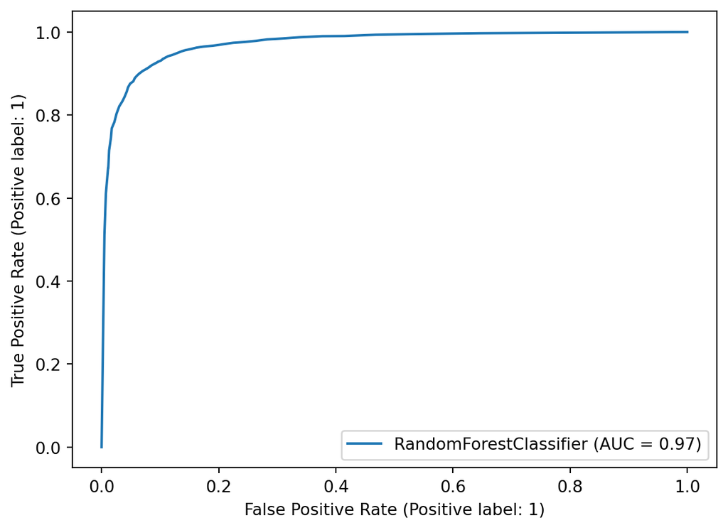

```python
metrics.RocCurveDisplay.from_estimator(test, x_test, y_test)
```

*This data below gives the accuracy on a scale of 0 to 1, and it also gives you the true negatives, that is, the 0s, and the true positives, the 1s.*

```python
print(metrics.classification_report(y_pred, y_test))
accuracy_score(y_pred, y_test)
```

```
              precision    recall  f1-score   support

           0       0.90      0.89      0.89      2925
           1       0.93      0.94      0.94      4866

    accuracy                           0.92      7791
   macro avg       0.91      0.91      0.91      7791
weighted avg       0.92      0.92      0.92      7791
```

```
0.9192658195353614
```

Back to top